# Trabajo

Hector

2023-10-08

## Librerias utilizadas

```r
library("readxl")
library("plm")
library("forecast")
library("dplyr")
```

```r
library("tidyr")
library("ggplot2")
# Función para convertir el trimestre a fecha
convertir_a_fecha <- function(trimestre) {
  año <- substr(trimestre, 1, 4)
  t <- substr(trimestre, 6, 6)

  # Definir el mes de inicio para cada trimestre
  mes_inicio <- ifelse(t == "1", "01",
                       ifelse(t == "2", "04",
                              ifelse(t == "3", "07", "10")))

  fecha = as.Date(paste(año, mes_inicio, "01", sep = "-"))
  return(format(fecha, "%Y-%m-%d"))
}
```

# Trabajo Académico

## Introducción

Hoy en día la accesibilidad a la vivienda es un problema presente en nuestra sociedad. Nosotros vamos a intentar analizarlo desde el punto de vista del precio de la vivienda.

## Pregunta

¿Como se comporta el precio de la vivienda? ¿Como se relaciona el precio de la vivienda con el IPC, las personas activas y el coste salarial?

## Descripción de los datos

- CCAA: comunidad autonóma (individuos) (no tenemos datos ni de Ceuta ni de Melilla)
- Periodo: periodo de tiempo, desde 2017 hasta 2020 divididos por trimestres
- IPC: indices de precio de consumo
- Personas activas: el número de personas activas
- Precio vivienda: es un índice confeccionado en España por el Instituto Nacional de Estadística que fue publicado con el propósito de reflejar la evolución de precios de la vivienda.
- Coste_salarial_total: se refiere al gasto total que una empresa incurre al pagar los salarios y las prestaciones a sus empleados. Se incluyen los sectores de industria, construcción y servicios

Destacar que son datos de panel ya que contienen una serie temporal por cada unidad de unos datos de corte transversal. Al ser datos de panel tenemos individuos (CCAA) y el periodo de tiempo (periodo) y el número de observaciones coincide con el resultado de multiplicar el número de periodos de tiempo por el número de individuos 17x12=204 que son nuestras observaciones.

La pregunta a la que responderemos con estos datos es si influyen y en el caso de que influyan de que forma, el ipc, el coste salarial total y el número de personas activas sobre el precio de la vivienda.

## Carga de datos

Abrimos nuestro fichero de datos y cargamos los datos en un panel data frame. Le especificamos los dos índices que son la comundiad autónoma (CCAA) y el periodo de tiempo (Periodo)

```r
datos <- read_excel("./datos_trabajo.xlsx")
data <- pdata.frame(datos, index = c("CCAA","Periodo"), drop.index = FALSE, row.names = TRUE)

head(data)
```

```
##                       CCAA Periodo      IPC Personas_activas Precio_vivienda
## Andalucía-2017T1 Andalucía  2017T1 94.47567           3980.8         104.051
## Andalucía-2017T2 Andalucía  2017T2 95.31533           3962.1         105.676
## Andalucía-2017T3 Andalucía  2017T3 94.67267           3957.9         106.913
## Andalucía-2017T4 Andalucía  2017T4 96.26667           3932.2         107.763
## Andalucía-2018T1 Andalucía  2018T1 95.32267           3943.4         108.283
## Andalucía-2018T2 Andalucía  2018T2 97.00000           3942.7         110.695
##                  Coste.laboral.total Coste.salarial.total
## Andalucía-2017T1             2199.80              1602.09
## Andalucía-2017T2             2340.30              1743.40
## Andalucía-2017T3             2225.59              1632.62
## Andalucía-2017T4             2362.04              1768.78
## Andalucía-2018T1             2159.14              1573.94
## Andalucía-2018T2             2297.25              1712.06
```

Convertimos a numérico las columnas Personas_activas y Precio_vivienda que estaban en tipo texto y cambiamos el nombre de la columna Coste.salarial.total a Coste_salarial_total.

```r
data$Personas_activas = as.numeric(data$Personas_activas)
data$Precio_vivienda = as.numeric(data$Precio_vivienda)
colnames(data)[colnames(data) == "Coste.salarial.total"] <- "Coste_salarial_total"

head(data)
```

```
##                       CCAA Periodo      IPC Personas_activas Precio_vivienda
## Andalucía-2017T1 Andalucía  2017T1 94.47567           3980.8         104.051
## Andalucía-2017T2 Andalucía  2017T2 95.31533           3962.1         105.676
## Andalucía-2017T3 Andalucía  2017T3 94.67267           3957.9         106.913
## Andalucía-2017T4 Andalucía  2017T4 96.26667           3932.2         107.763
## Andalucía-2018T1 Andalucía  2018T1 95.32267           3943.4         108.283
## Andalucía-2018T2 Andalucía  2018T2 97.00000           3942.7         110.695
##                  Coste.laboral.total Coste_salarial_total
## Andalucía-2017T1             2199.80              1602.09
## Andalucía-2017T2             2340.30              1743.40
## Andalucía-2017T3             2225.59              1632.62
## Andalucía-2017T4             2362.04              1768.78
## Andalucía-2018T1             2159.14              1573.94
## Andalucía-2018T2             2297.25              1712.06
```

## Análisis exploratorio

Lo primero que vamos a hacer es ver el comportamiento de los datos que manejamos. A continuación, observamos la evolución de la media para todas las comunidades de nuestras variables a lo largo del tiempo.

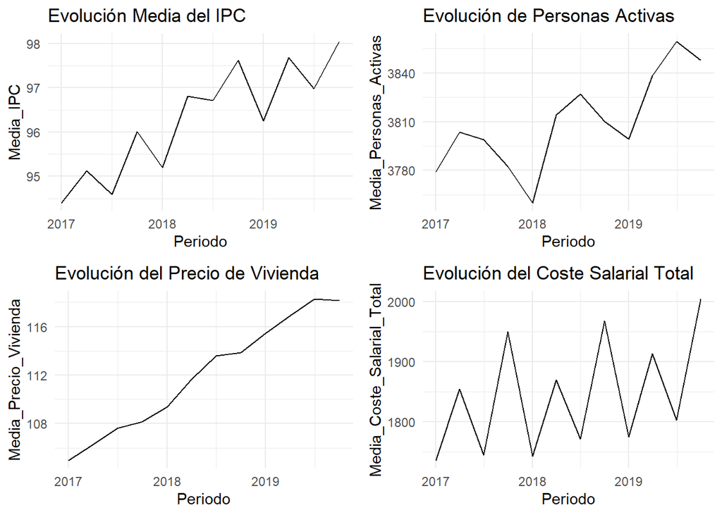

```r
# Calcular la media de cada variable por periodo
medias_por_periodo <- data %>%
  group_by(Periodo) %>%
  summarise(
    Media_IPC = mean(IPC, na.rm = TRUE),
    Media_Personas_Activas = mean(Personas_activas, na.rm = TRUE),
    Media_Precio_Vivienda = mean(Precio_vivienda, na.rm = TRUE),
    Media_Coste_Salarial_Total = mean(Coste_salarial_total, na.rm = TRUE)
  )

medias_por_periodo$Periodo <- sapply(as.character(medias_por_periodo$Periodo), convertir_a_fecha)
medias_por_periodo$Periodo = as.Date(medias_por_periodo$Periodo)

# Crear los gráficos
p1 <- ggplot(medias_por_periodo, aes(x = Periodo, y = Media_IPC)) +
  geom_line() +
  theme_minimal() +
  ggtitle("Evolución Media del IPC")

p2 <- ggplot(medias_por_periodo, aes(x = Periodo, y = Media_Personas_Activas)) +
  geom_line() +
  theme_minimal() +
  ggtitle("Evolución de Personas Activas")

p3 <- ggplot(medias_por_periodo, aes(x = Periodo, y = Media_Precio_Vivienda)) +
  geom_line() +
  theme_minimal() +
  ggtitle("Evolución del Precio de Vivienda")

p4 <- ggplot(medias_por_periodo, aes(x = Periodo, y = Media_Coste_Salarial_Total)) +
  geom_line() +
  theme_minimal() +
  ggtitle("Evolución del Coste Salarial Total")

# Mostrar los gráficos en un grid
library(gridExtra)
grid.arrange(p1, p2, p3, p4, ncol = 2)
```

1. **Evolución Media del IPC**: El IPC muestra fluctuaciones a lo largo del tiempo, con un leve aumento en la tendencia. Como medida de la inflación, un aumento en el IPC podría influir en el poder adquisitivo y, por tanto, en la capacidad de los consumidores para comprar viviendas.
2. **Evolución de Personas Activas**: Hay una tendencia general ascendente en el número de personas activas, lo que puede estar relacionado con una economía en crecimiento. Un aumento en la fuerza laboral activa podría correlacionarse con una mayor demanda de vivienda, ya que más personas podrían tener los medios para comprar o alquilar.
3. **Evolución del Precio de Vivienda**: Esta línea muestra una tendencia claramente ascendente, lo que indica un incremento constante en el precio de la vivienda. Esta variable es el foco principal del análisis y es la única que no presenta un patrón estacional.
4. **Evolución del Coste Salarial Total**: El coste salarial total también presenta una tendencia al alza, lo cual podría interpretarse como un aumento en los costos para las empresas. Aunque esta variable no se relaciona directamente con el mercado de la vivienda, los salarios más altos podrían aumentar la capacidad de los trabajadores para adquirir viviendas, afectando así la demanda y, posiblemente, los precios.

Cabe destacar que el patrón estacional del coste salarial y de la evolución del PIB es similar, ambos presentan una forma de M cada año, en cambio la evolución de personas activas es más parecido a una U invertida, con su pico en el segundo o tercer trimestre del año.

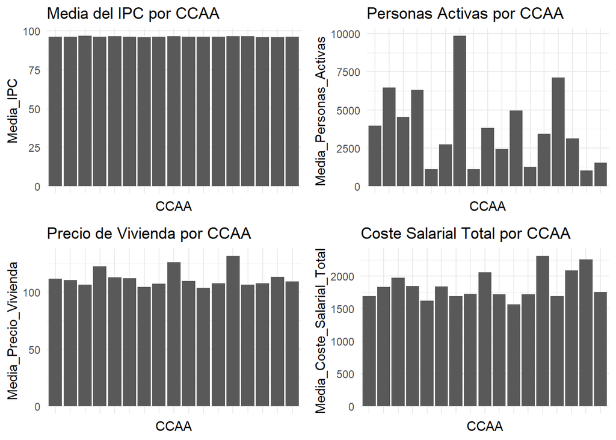

```r
# Calcular la media de cada variable por CCAA
medias_por_CCAA <- data %>%
  group_by(CCAA) %>%
  summarise(
    Media_IPC = mean(IPC, na.rm = TRUE),
    Media_Personas_Activas = mean(Personas_activas, na.rm = TRUE),
    Media_Precio_Vivienda = mean(Precio_vivienda, na.rm = TRUE),
    Media_Coste_Salarial_Total = mean(Coste_salarial_total, na.rm = TRUE)
  )

p1 <- ggplot(medias_por_CCAA, aes(x = CCAA, y = Media_IPC)) +
  geom_bar(stat = 'identity') +
  theme_minimal() +
  ggtitle("Media del IPC por CCAA") +
  theme(axis.text.x = element_blank(),
        axis.ticks.x = element_blank())


p2 <- ggplot(medias_por_CCAA, aes(x = CCAA, y = Media_Personas_Activas)) +
  geom_bar(stat = 'identity') +
  theme_minimal() +
  ggtitle("Personas Activas por CCAA") +
  theme(axis.text.x = element_blank(),
        axis.ticks.x = element_blank())

p3 <- ggplot(medias_por_CCAA, aes(x = CCAA, y = Media_Precio_Vivienda)) +
  geom_bar(stat = 'identity') +
  theme_minimal() +
  ggtitle("Precio de Vivienda por CCAA") +
  theme(axis.text.x = element_blank(),
        axis.ticks.x = element_blank())

p4 <- ggplot(medias_por_CCAA, aes(x = CCAA, y = Media_Coste_Salarial_Total)) +
  geom_bar(stat = 'identity') +
  theme_minimal() +
  ggtitle("Coste Salarial Total por CCAA") +
  theme(axis.text.x = element_blank(),
        axis.ticks.x = element_blank())

# Mostrar los gráficos en un grid
library(gridExtra)
grid.arrange(p1, p2, p3, p4, ncol = 2)
```

1. **Evolución Media del IPC**: Las barras parecen tener alturas similares, lo que indicaría que el IPC medio no varía significativamente entre las CCAA. Sin embargo, la uniformidad del IPC no implica necesariamente una uniformidad en los precios de la vivienda, ya que pueden estar afectados por factores locales específicos.
2. **Evolución de Personas Activas**: Hay una variabilidad considerable en el número medio de personas activas entre las CCAA. Esto podría reflejar diferencias en la demografía, el mercado laboral y la economía de las regiones. Las regiones con más personas activas podrían tener una mayor demanda de vivienda, lo que a su vez podría influir en los precios.
3. **Evolución del Precio de Vivienda**: Las diferencias en las medias del precio de vivienda entre las CCAA son notables y pueden reflejar la variación en la demanda de vivienda, el ingreso disponible y las preferencias de los consumidores. La evolución del precio de la vivienda es el resultado de múltiples factores, incluyendo la economía local, la oferta y demanda de viviendas, y las políticas de vivienda.
4. **Evolución del Coste Salarial Total**: Al igual que con las personas activas, hay una variación significativa entre las CCAA en el coste salarial total medio. Esto podría indicar diferencias en las estructuras del mercado laboral y los niveles de ingreso, lo que a su vez podría afectar a la capacidad de los individuos para comprar viviendas.

Vamos a ver en más profundidad nuestra variable explicada, el precio de la vivienda.

```r
# Libraries
library(tidyverse)
library(hrbrthemes)
library(kableExtra)
options(knitr.table.format = "html")
library(babynames)
library(viridis)
library(DT)
```

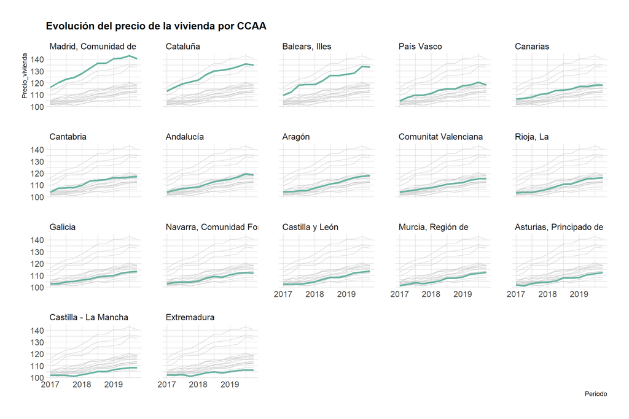

```r
library(plotly)
# Reordenar las CCAA basándose en la media del precio de la vivienda
tmp <- data %>%
  mutate(Periodo = as_datetime(sapply(Periodo, convertir_a_fecha))) %>%
  mutate(CCAA = fct_reorder(CCAA, Precio_vivienda, .fun = mean, .desc=TRUE))%>%
    mutate(name2=CCAA)

p = tmp %>%
  ggplot( aes(x=Periodo, y=Precio_vivienda)) +
    geom_line( data=tmp %>% dplyr::select(-CCAA), aes(group=name2), color="grey", size=0.5, alpha=0.5) +
    geom_line( aes(color=CCAA), color="#69b3a2", size=1.2 )+
    scale_color_viridis(discrete = TRUE) +
    theme_ipsum() +
    theme(
      legend.position="none",
      plot.title = element_text(size=14),
      panel.grid = element_blank()
    ) +
    ggtitle("Evolución del precio de la vivienda por CCAA") +
    facet_wrap(~CCAA)
p
```

[output not shown]

[figure not shown]

```r
# Reorder the CCAA based on the average housing price and mutate to create a new column for the name
data <- data %>%
  mutate(CCAA = fct_reorder(CCAA, Precio_vivienda, .fun = mean, .desc=TRUE)) %>%
  mutate(name2=CCAA)

# Create the plot
p <- data %>%
  ggplot(aes(x=Periodo, y=Precio_vivienda)) +
  geom_line(data=data %>% select(-CCAA), aes(group=name2), color="grey", size=0.5, alpha=0.5) +
  geom_line(aes(color=CCAA), color="#69b3a2", size=1.2) +
  scale_color_viridis(discrete = TRUE) +
  theme_ipsum() +
  theme(
    legend.position="none",
    plot.title = element_text(size=14),
    panel.grid = element_blank()
  ) +
  ggtitle("Evolución del precio de la vivienda por CCAA") +
  facet_wrap(~CCAA)

# Display the plot
print(p)
```

En este conjunto de gráficos, realizamos una exploración visual de la dinámica del precio de la vivienda en las Comunidades Autónomas de España entre 2017 y 2019. El gráfico facilita una comparación inmediata entre comunidades al resaltar la trayectoria de una comunidad específica en cada panel, mientras se muestra el contexto proporcionado por las demás comunidades en un plano secundario.

Observamos una tendencia general al alza en los precios de la vivienda a lo largo del periodo estudiado, lo que podría estar en línea con un entorno de recuperación económica, condiciones favorables de financiamiento y posiblemente una demanda creciente impulsada por factores demográficos y de mercado.

Algunos puntos destacables incluyen:

- **Madrid y Cataluña**: Estas comunidades muestran una marcada tendencia alcista en los precios de la vivienda, superando a la mayoría de las otras regiones. Esto podría reflejar su condición de centros económicos y culturales, con una demanda de vivienda robusta.
- **Variabilidad entre Comunidades**: Aunque la tendencia general es al alza, la variabilidad en la tasa de crecimiento es notable. Comunidades como Extremadura y Castilla-La Mancha muestran un crecimiento más moderado, lo que podría sugerir diferencias en las presiones del mercado local o en la actividad económica.

Estos gráficos muestran que si que existen diferencias entre comunidades a pesar de que la evolución es más o menos igual para toda españa. A continuación, vamos a tratar de resolver las preguntas formuladas anteriormente.

## Modelos de datos de panel

Como la pregunta que nos planteamos es como influye el ipc, el coste salarial total y el número de personas activas en el precio de la vivienda, los modelos que se trabajarán a continuación tendrá como variable dependiente el precio de la vivienda y como variable independiente el número de personas activas, el ipc y el coste salarial total.

A continuación, vamos a estimar los distintos modelos e interpretar los coeficientes.

- Modelo de pool de datos
- Efectos fijos individuales MCVD
- Efectos aleatorios

Una vez hechos los modelos, elegiremos tanto desde el punto de vista teórico como con los contrastes de homogeneidad y de Hausman que modelo describe mejor el precio de la vivienda.

### Modelo Pool de datos

```r
pool_datos <- plm(Precio_vivienda ~ Personas_activas + IPC + Coste_salarial_total, data = data, model = "pooling")

summary(pool_datos)
```

```
## Pooling Model
##
## Call:
## plm(formula = Precio_vivienda ~ Personas_activas + IPC + Coste_salarial_total,
##     data = data, model = "pooling")
##
## Balanced Panel: n = 17, T = 12, N = 204
##
## Residuals:
##      Min.   1st Qu.    Median   3rd Qu.      Max.
## -13.52736  -4.72225  -0.31311   3.08416  20.79708
##
## Coefficients:
##                         Estimate  Std. Error t-value  Pr(>|t|)
## (Intercept)          -1.6969e+02  3.9147e+01 -4.3346 2.312e-05 ***
## Personas_activas     -7.3953e-05  2.0316e-04 -0.3640    0.7162
## IPC                   2.5965e+00  4.1746e-01  6.2198 2.856e-09 ***
## Coste_salarial_total  1.7343e-02  2.2138e-03  7.8338 2.732e-13 ***
## ---
## Signif. codes:  0 '***' 0.001 '**' 0.01 '*' 0.05 '.' 0.1 ' ' 1
##
## Total Sum of Squares:    16593
## Residual Sum of Squares: 9652.2
## R-Squared:      0.41828
## Adj. R-Squared: 0.40955
## F-statistic: 47.936 on 3 and 200 DF, p-value: < 2.22e-16
```

El intercept es -169.69. Este valor es la estimación del precio de la vivienda cuando todas las demás variables son cero.

El coeficiente asociado a la variable “Personas_activas” es -7.3953e-05. No es estadísticamente significativo a un nivel de confianza del 95% (p-value = 0.7162).

El coeficiente asociado al IPC es 2.5965. Es estadísticamente significativo (p-value < 0.001), y positivo. Cada unidad de aumento en el IPC se asocia con un aumento de 2.5965 en el precio de la vivienda.

El coeficiente asociado al “Coste_salarial_total” es 0.017343. Es estadísticamente significativo (p-value < 0.001) y positivo. Cada unidad de aumento en el coste salarial total se asocia con un aumento de 0.017343 en el precio de la vivienda.

El valor F es 47.936 con un p-value muy pequeño (< 2.22e-16). Esto sugiere que al menos una de las variables independientes es significativa en la explicación de la variabilidad en el precio de la vivienda.

En resumen, el modelo sugiere que el IPC y el Coste Salarial Total son variables significativas y positivas en la explicación del precio de la vivienda, mientras que la variable “Personas_activas” no parece tener un impacto significativo.

### Efectos fijos individuales MCVD

Consideramos efectos fijos para cada Comunidad Autónoma (CCAA).

```r
efectos_fijos <- plm(Precio_vivienda ~ Personas_activas + IPC + Coste_salarial_total + as.factor(CCAA), data = data, model="pooling")

summary(efectos_fijos)
```

```
## Pooling Model
##
## Call:
## plm(formula = Precio_vivienda ~ Personas_activas + IPC + Coste_salarial_total +
##     as.factor(CCAA), data = data, model = "pooling")
##
## Balanced Panel: n = 17, T = 12, N = 204
##
## Residuals:
##     Min.  1st Qu.   Median  3rd Qu.     Max.
## -7.49705 -1.64374  0.12028  1.47490  8.31944
##
## Coefficients:
##                                               Estimate  Std. Error  t-value
## (Intercept)                                -2.5324e+02  1.6690e+01 -15.1733
## Personas_activas                            9.5502e-03  2.4564e-03   3.8879
## IPC                                         4.0500e+00  2.1200e-01  19.1041
## Coste_salarial_total                       -1.6648e-02  2.4623e-03  -6.7613
## as.factor(CCAA)Cataluña                    -1.3258e+01  1.5381e+00  -8.6196
## as.factor(CCAA)Balears, Illes              -4.3505e+01  7.1891e+00  -6.0515
## as.factor(CCAA)País Vasco                   5.4983e+00  5.9361e+00   0.9262
## as.factor(CCAA)Canarias                    -8.7584e+00  6.1411e+00  -1.4262
## as.factor(CCAA)Cantabria                   -1.9666e+01  2.3587e+00  -8.3379
## as.factor(CCAA)Andalucía                   -3.4966e+01  2.1765e+00 -16.0652
## as.factor(CCAA)Aragón                      -5.7014e+01  7.5271e+00  -7.5744
## as.factor(CCAA)Comunitat Valenciana        -2.1651e+01  3.1098e+00  -6.9623
## as.factor(CCAA)Rioja, La                   -1.3119e+01  5.0172e+00  -2.6148
## as.factor(CCAA)Galicia                     -1.1281e+01  5.7177e+00  -1.9730
## as.factor(CCAA)Navarra, Comunidad Foral de -2.3096e+01  1.3641e+00 -16.9320
## as.factor(CCAA)Castilla y León             -1.0615e+01  5.9977e+00  -1.7699
## as.factor(CCAA)Murcia, Región de           -7.1565e+01  9.1694e+00  -7.8048
## as.factor(CCAA)Asturias, Principado de     -4.2828e+01  3.0079e+00 -14.2386
## as.factor(CCAA)Castilla - La Mancha        -9.7139e+01  1.5794e+01  -6.1503
## as.factor(CCAA)Extremadura                 -5.3487e+01  4.1906e+00 -12.7637
##                                             Pr(>|t|)
## (Intercept)                                < 2.2e-16 ***
## Personas_activas                            0.000141 ***
## IPC                                        < 2.2e-16 ***
## Coste_salarial_total                       1.755e-10 ***
## as.factor(CCAA)Cataluña                    3.035e-15 ***
```

[output cut: 8 more lines]

```
## as.factor(CCAA)Galicia                      0.049993 *
## as.factor(CCAA)Navarra, Comunidad Foral de < 2.2e-16 ***
## as.factor(CCAA)Castilla y León              0.078403 .
## as.factor(CCAA)Murcia, Región de           4.347e-13 ***
## as.factor(CCAA)Asturias, Principado de     < 2.2e-16 ***
## as.factor(CCAA)Castilla - La Mancha        4.702e-09 ***
## as.factor(CCAA)Extremadura                 < 2.2e-16 ***
## ---
## Signif. codes:  0 '***' 0.001 '**' 0.01 '*' 0.05 '.' 0.1 ' ' 1
##
## Total Sum of Squares:    16593
## Residual Sum of Squares: 1227.2
## R-Squared:      0.92604
## Adj. R-Squared: 0.9184
## F-statistic: 121.247 on 19 and 184 DF, p-value: < 2.22e-16
```

El coeficiente asociado a la variable “Personas_activas” es 0.00955. Es estadísticamente significativo (p-value < 0.001), y positivo. Cada unidad de aumento en las personas activas se asocia con un aumento de 0.00955 en el precio de la vivienda.

El coeficiente asociado al IPC es 4.05. Es estadísticamente significativo (p-value < 0.001), y positivo. Cada unidad de aumento en el IPC se asocia con un aumento de 4.05 en el precio de la vivienda.

El coeficiente asociado al “Coste_salarial_total” es -0.01665. Es estadísticamente significativo (p-value < 0.001), y negativo. Cada unidad de aumento en el coste salarial total se asocia con una disminución de 0.01665 en el precio de la vivienda.

El modelo parece tener un buen ajuste y explica una gran proporción de la variabilidad en el precio de la vivienda. Las variables de personas activas, IPC y coste salarial total son significativas en la predicción del precio de la vivienda, y también hay diferencias significativas en los precios de vivienda entre las diferentes CCAA.

### Efectos aleatorios

```r
efectos_aleatorios <- plm(Precio_vivienda ~ Personas_activas + IPC + Coste_salarial_total , data = data, model = "random")
summary(efectos_aleatorios)
```

```
## Oneway (individual) effect Random Effect Model
##    (Swamy-Arora's transformation)
##
## Call:
## plm(formula = Precio_vivienda ~ Personas_activas + IPC + Coste_salarial_total,
##     data = data, model = "random")
##
## Balanced Panel: n = 17, T = 12, N = 204
##
## Effects:
##                  var std.dev share
## idiosyncratic  6.670   2.583 0.144
## individual    39.578   6.291 0.856
## theta: 0.8823
##
## Residuals:
##      Min.   1st Qu.    Median   3rd Qu.      Max.
## -6.115484 -1.807198 -0.082073  1.420223 10.092501
##
## Coefficients:
##                         Estimate  Std. Error  z-value  Pr(>|z|)
## (Intercept)          -2.5445e+02  1.8309e+01 -13.8972 < 2.2e-16 ***
## Personas_activas      8.5802e-05  6.7227e-04   0.1276    0.8984
## IPC                   4.0642e+00  2.1855e-01  18.5960 < 2.2e-16 ***
## Coste_salarial_total -1.3654e-02  2.5485e-03  -5.3578 8.424e-08 ***
## ---
## Signif. codes:  0 '***' 0.001 '**' 0.01 '*' 0.05 '.' 0.1 ' ' 1
##
## Total Sum of Squares:    5033.4
## Residual Sum of Squares: 1597.5
## R-Squared:      0.68263
## Adj. R-Squared: 0.67787
## Chisq: 430.173 on 3 DF, p-value: < 2.22e-16
```

El intercept es -254.45. Este valor es la estimación del precio de la vivienda cuando todas las demás variables son cero, y representa la media de los interceptos individuales.

El coeficiente asociado a la variable “Personas_activas” es 8.5802e-05. No es estadísticamente significativo a un nivel de confianza del 95% (p-value = 0.8984).

El coeficiente asociado al IPC es 4.0642. Es estadísticamente significativo (p-value < 0.001), y positivo. Cada unidad de aumento en el IPC se asocia con un aumento de 4.0642 en el precio de la vivienda.

El coeficiente asociado al “Coste_salarial_total” es -0.013654. Es estadísticamente significativo (p-value < 0.001), y negativo. Cada unidad de aumento en el coste salarial total se asocia con una disminución de 0.013654 en el precio de la vivienda.

El valor de chi-cuadrado es 430.173 con un p-value muy pequeño (< 2.22e-16). Esto sugiere que al menos una de las variables independientes es significativa en la explicación de la variabilidad en el precio de la vivienda.

La proporción de error idiosincrático es del 14%, mientras que la individual del 86%. La proporción del 14.4% para el efecto idiosincrático significa que una parte relativamente pequeña de la variabilidad total en el precio de la vivienda se debe a factores específicos de cada observación que no están explicados por las variables incluidas en tu modelo. Por otro lado, la proporción del 85.6% para el efecto individual significa que la mayoría de la variabilidad total en el precio de la vivienda se debe a diferencias sistemáticas entre las entidades (individuos) que no están capturadas por las variables incluidas en el modelo.

El modelo de efectos aleatorios tiene en cuenta la variabilidad no observada específica a cada entidad (efecto individual) y la variabilidad no observada específica a cada observación (efecto idiosincrático). Los resultados sugieren que una parte significativa de la variabilidad en el precio de la vivienda se debe a efectos individuales, y las variables IPC y Coste Salarial Total son significativas en la predicción del precio de la vivienda. La variable Personas Activas no parece ser significativa en este modelo.

### Conclusiones (Elección del modelo)

Desde el punto de vista teórico, entre un modelo de pool de datos y un modelo de efectos fijos individuales eligiremos el modelo de efectos fijos individuales porque existen diferencias en el precio de la vivienda en cada CCAA. No es lo mismo el precio de la vivienda en Madrid que en Castilla-La-Mancha o Extremadura.

Y entre un modelo de efectso fijos o aleatorios, elegiremos el modelo de efectos fijos ya que la muestra no es aleatoria.

Desde el punto de vista de los contrastes, aplicamos en primer lugar el contraste de homogeneidad para elegir entre pool de datos o efectos fijos.

H0: no hay diferencias entre los individuos, todas las alfas son iguales H1: Hay diferencias entre individuos, y por tanto es preferible tenerlas en cuenta

```r
pFtest(efectos_fijos, pool_datos)
```

```
##
##  F test for individual effects
##
## data:  Precio_vivienda ~ Personas_activas + IPC + Coste_salarial_total +  ...
## F = 78.947, df1 = 16, df2 = 184, p-value < 2.2e-16
## alternative hypothesis: significant effects
```

Como el p-valor < 0.05, rechazamos H0 y por tanto existirán diferencias entre los individuos y nos quedaremos con el modelo de efectos fijos.

A continuación, comparamos el modelo de efectos fijos con el modelo de efectos aleatorios con el test de Hausman

H0: No hay diferencias entre los estimadores por EF o EA, beta de efectos fijos = beta de efectos aleatorios H1: Hay diferencias entre estimadores, probablemente porque los EA estén correlacionados con las regresoras, beta de efectos fijos distinto beta de efectos aleatorios

```r
phtest(efectos_fijos, efectos_aleatorios)
```

```
##
##  Hausman Test
##
## data:  Precio_vivienda ~ Personas_activas + IPC + Coste_salarial_total +  ...
## chisq = 15.011, df = 3, p-value = 0.001807
## alternative hypothesis: one model is inconsistent
```

Como el p-valor < 0.05, rechazamos H0 y por tanto existirán diferencias entre los estimadores y nos quedaremos con el modelo de efectos fijos.

Se puede concluir, que el modelo que mejor explica el precio de la vivienda es el modelo de efectos fijos individuales MCVD.

# Series temporales

En esta segunda parte del estudio, nos enfocamos en el análisis del precio de la vivienda en la Comunidad Valenciana como una serie temporal. Abarcamos desde el 2007 hasta la actualidad (tercer trimestre de 2023) con una granularidad trimestral. Este período es especialmente significativo, ya que incluye tanto el impacto de la crisis financiera global de 2008 como las fluctuaciones económicas subsiguientes, incluyendo la reciente pandemia de COVID-19. Durante el análisis vamos a descubrir la naturaleza de la serie y vamos a tratar de diseñar un modelo econométrico que prediga el índice del precio de la vivienda. Esto nos permitirá adelantarnos al mercado de bienes raices y saber el estado del mismo. En nuestro caso queremos ser capaces de realizar muy buenas predicciones a un cuatrimestre vista y a medio largo plazo.

Debido a que vamos a cambiar ligeramente nuestra fuente de datos volvermos a realizar una análisis descriptivo para entender el comportamietno del mercado. Seguidamente, aplicaremos los análisis de series temporales aprendidos durante el curso y alguno extra para conseguir un modelo de predicción lo más exacto posible. Es posible que acabemos con dos modelos predictivos y que uno prediga bien a corto plazo y otro a medio plazo.

## Carga de datos

```r
# abrimos el fichero donde se encuentran nuestros datos
df <- read_excel("./precio_vivienda_trabajo.xlsx")
```

```r
# Como los trimestres están ordenados en sentido contrario al necesario para trabajar series temporales, cambiamos el orden
# Ordenar las filas por la columna de fechas (B)
df <- df[order(as.character(df$Periodo)), ]
head(df)
```

```
## # A tibble: 6 × 2
##   Periodo Precio_vivienda
##   <chr>             <dbl>
## 1 2007T1             137.
## 2 2007T2             142.
## 3 2007T3             144.
## 4 2007T4             146.
## 5 2008T1             147.
## 6 2008T2             146.
```

## Análisis exploratorio

El primer paso de nuestro análisis es comprender la forma de nuestros datos e identificar grandes factores socio-económicos que puedan haber afectado. Ya que es importante identificar eventos excepcionales que puedan alterar los datos y sesgar nuestro modelo.

```r
# Convertir periodo a fecha
df$Periodo <- sapply(df$Periodo, convertir_a_fecha)
df$Periodo = as.Date(df$Periodo)
```

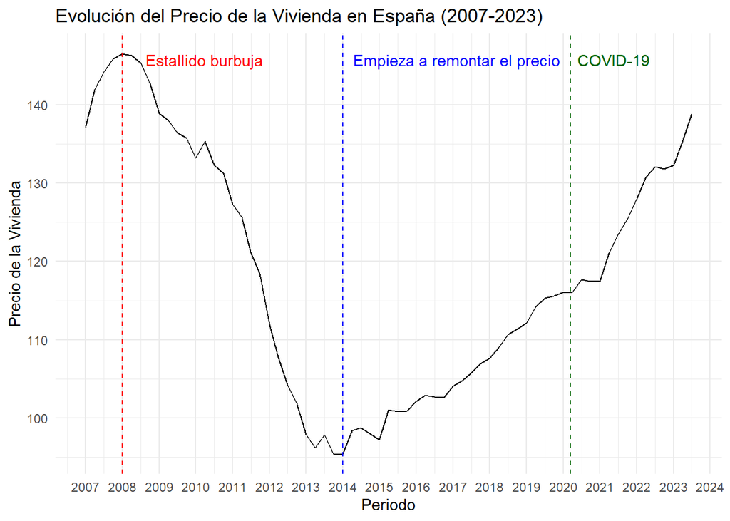

```r
library(ggplot2)

# Crear el gráfico
ggplot(df, aes(x = Periodo, y = Precio_vivienda)) +
  geom_line() +  # Línea para mostrar la evolución del precio
  geom_vline(xintercept = as.Date("2008-01-01"), linetype = "dashed", color = "red") +  # Línea vertical en 2012
  annotate("text", x = as.Date("2008-01-01"), y = max(df$Precio_vivienda), label = "Estallido burbuja", hjust = -0.2, vjust = 1, color = "red") +
  labs(title = "Evolución del Precio de la Vivienda en España (2007-2023)",
       x = "Periodo",
       y = "Precio de la Vivienda") +
  geom_vline(xintercept = as.Date("2014-01-01"), linetype = "dashed", color = "blue") +  # Línea vertical en 2012
  annotate("text", x = as.Date("2014-01-01"), y = max(df$Precio_vivienda), label = "Empieza a remontar el precio", hjust = -0.05, vjust = 1, color = "blue") +
  geom_vline(xintercept = as.Date("2020-03-12"), linetype = "dashed", color = "darkgreen") +  # Línea vertical en 2012
  annotate("text", x = as.Date("2020-03-12"), y = max(df$Precio_vivienda), label = "COVID-19", hjust = -0.1, vjust = 1, color = "darkgreen") +
  theme_minimal() +
  scale_x_date(date_breaks = "1 year", date_labels = "%Y") # Formato del eje X
```

La línea continua representa la serie temporal del precio, evidenciando tres momentos críticos en el mercado inmobiliario español, marcados por líneas verticales punteadas y anotaciones explicativas.

Primero, la línea roja punteada señala el año 2008, coincidiendo con el estallido de la burbuja inmobiliaria. Aquí, se observa un pico seguido de un descenso abrupto, reflejando la caída de precios post-crisis financiera. Este fenómeno marcó el comienzo de un periodo recesivo en el que los precios tocaron su punto más bajo el último trimestre de 2013.

Posteriormente, la línea azul punteada 2014 sugieren un punto de inflexión donde se empieza a percibir una recuperación gradual de los precios. Esta tendencia ascendente indica un fortalecimiento del mercado que podría estar vinculado a mejoras en la economía española y un incremento en la demanda de vivienda.

Finalmente, la línea punteada verde oscura resalta el impacto de la pandemia de COVID-19 en marzo de 2020. Contrario a lo esperado, después de un breve periodo de estancamiento, el gráfico muestra un aumento sorprendente en los precios, lo que podría deberse a una combinación de factores como políticas de estímulo, cambios en las preferencias de vivienda post-confinamiento, y una bajada en las tasas de interés.

Este análisis gráfico sirve como una herramienta esencial para comprender la dinámica del mercado inmobiliario español. A partir de lo que vemos visto podríamos dividir la serie temporal en tres trozos separados por el estallido de la burbuja y cuando empieza a remontar el precio. Omitiremos el efecto de la pandemia porque no parece influir de manera notable en la tendencia del precio.

## Modelado de series temporales

Visto el comportamiento de los datos vamos a abordar el análisis desde dos perspectivas. En primera instancia trateremos de crear un modelo que sea capaz de predecir el precio de la vivienda entrenandolo con todos los datos que tenemos a nuestra disposición. Esto podría ayudar a que nuesto modelo sepa adaptarse a cambios de tendencia. Para ello, vamos a emplear un modelo ARIMA y calcularemos los mejores parámetros con la función auto.arima de forecast.

Por otra parte, trataremos de conseguir un modelo de predicción entrenandolo solo con los datos a partir de 2014, este modelo eliminará el sesgo provocado por la burbuja y puede que sea mejor para predicciones a medio plazo. Para este modelo utilizaremos:

- Regresión lineal
- Regresión cuadrática
- Regresión exponencial cuadrática
- Modelos ARIMA

### Modelo con todos los datos

Dada la forma de los datos podríamos tratar de ajustar el modelo con una función seno o coseno, sin embargo, además de no conocer su implementación, la velocidad de bajada es mayor a la velocidad de subida del precio. En carencia de una función matemática para aproximar optamos por un modelo ARIMA.

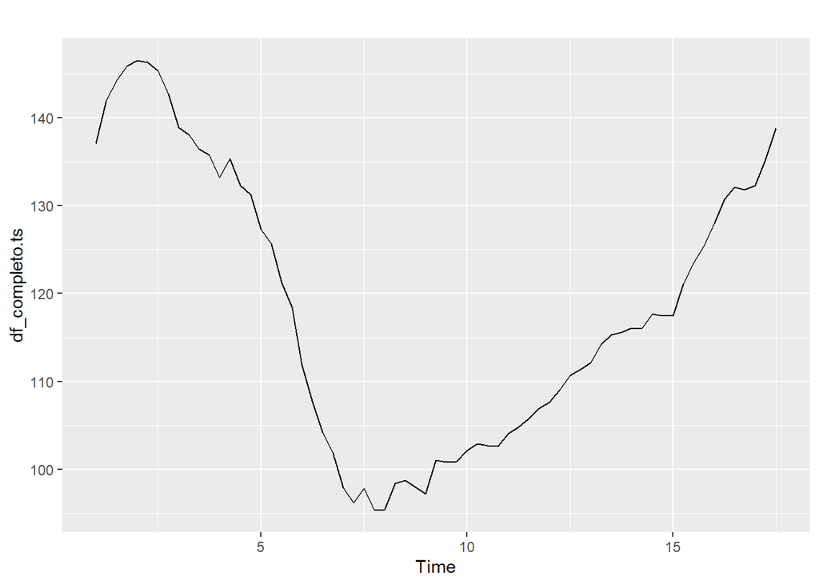

```r
df_completo = df

df_completo.ts<-ts(df_completo$Precio_vivienda, start=c(1,1), end=c(17,3), freq = 4)

autoplot(df_completo.ts)
```

Vamos a separar nuestros datos en entrenamiento y test para luego hacer la validación. Los datos test llegan hasta el primer trimestre de 2022.

- Datos test: [T1_2007 - T1_2022]
- Datos validación: [T2_2022 - T3_2023]

```r
completo_train_ends = c(16,1)
completo_valid_starts = c(16,2)
completo_valid_ends = c(17,3)

df_completo.ts.train<-window(df_completo.ts,start=c(1,1),end=completo_train_ends)
df_completo.ts.valid<-window(df_completo.ts,start=completo_valid_starts,end=completo_valid_ends)
```

#### Predicción a medio plazo

```r
df_completo.autoarima<-auto.arima(df_completo.ts.train)

df_completo.autoarima
```

```
## Series: df_completo.ts.train
## ARIMA(2,2,0)(0,0,1)[4]
##
## Coefficients:
##           ar1      ar2    sma1
##       -0.6533  -0.2343  0.5402
## s.e.   0.1280   0.1265  0.1205
##
## sigma^2 = 2.484:  log likelihood = -109.86
## AIC=227.72   AICc=228.46   BIC=236.03
```

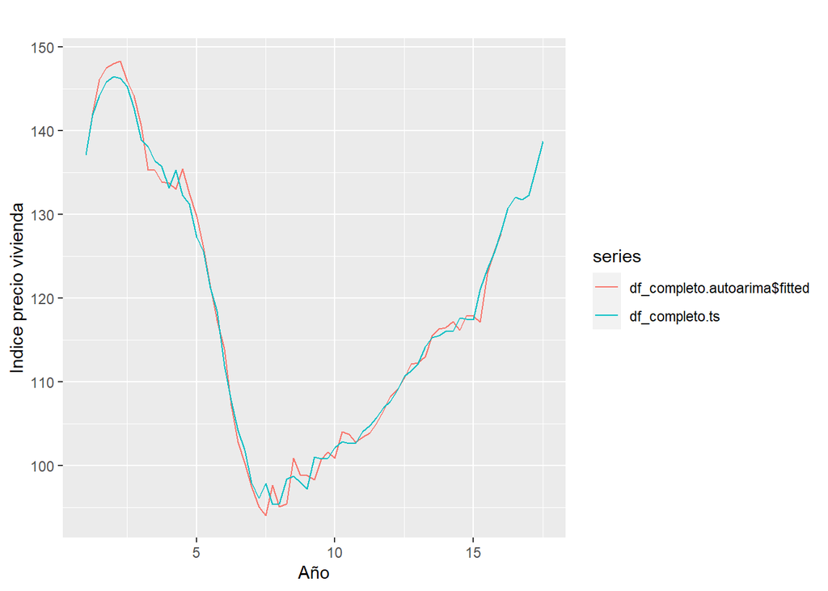

```r
autoplot(cbind(df_completo.autoarima$fitted,df_completo.ts), xlab="Año", ylab="Indice precio vivienda")
```

El gráfico presenta la comparación entre los valores reales del índice de precios de la vivienda (en azul) y las predicciones generadas por el modelo ARIMA(2,2,0)(0,0,1)[4] (en rojo) a lo largo del tiempo. Se observa una estrecha alineación entre ambas series, indicando un ajuste adecuado del modelo a los datos históricos.

Las predicciones del modelo capturan las tendencias y los cambios de dirección en el índice de precios, reflejando tanto el pico pre-crisis como el posterior declive y recuperación. Podemos observar como los periodos con mayor error son aquellos en los que se produce un cambio de tendencia, como en el punto en el que empiezan a remontar los precios de la vivienda

```r
library("TSPred")
```

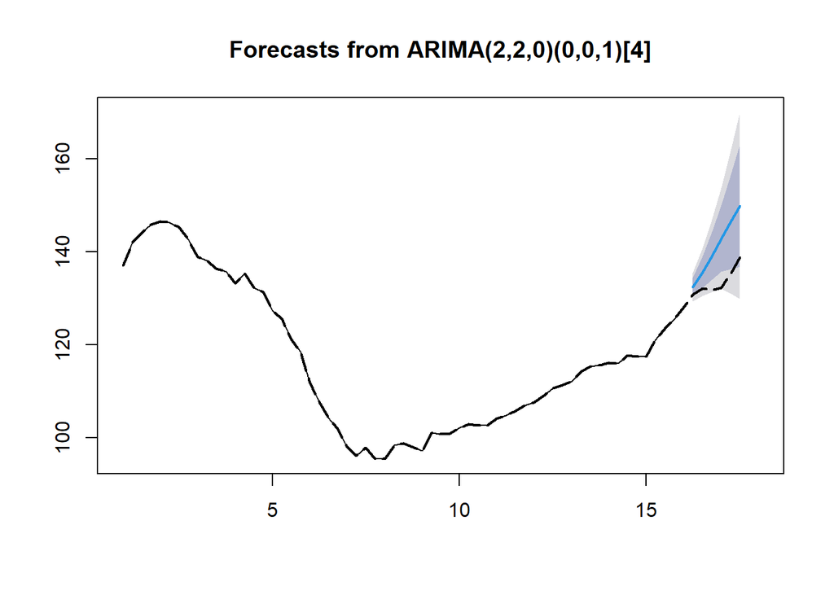

```r
df_completo.autoarima.pred.valid <- forecast(df_completo.autoarima, h = length(df_completo.ts.valid))

plotarimapred(df_completo.ts, df_completo.autoarima.pred.valid, xlim=c(1,18), range.percent = 0.001)
```

La línea de predicción parece iniciar cerca de la continuidad de la serie real, lo que indica un buen ajuste inicial del modelo. Sin embargo, el área de confianza se amplía progresivamente con el tiempo, indicando un aumento en la incertidumbre de las predicciones a medida que nos alejamos del último punto conocido. Esto se debe a que las predicciones de los modelos ARIMA se basan en la suposición de que las condiciones pasadas, reflejadas en la estructura autoregresiva y de medias móviles, se mantendrán en el futuro.

Con cada nuevo paso de predicción, los errores se acumulan y la base de información del modelo para realizar la predicción siguiente se debilita, ya que se basa cada vez más en predicciones en lugar de en observaciones reales. Este fenómeno es conocido como ‘decadencia de la predicción’. Además, eventos futuros no anticipados por el modelo, cambios en la tendencia subyacente, o el impacto de choques externos que no se han incorporado en el modelo histórico, pueden contribuir a una disminución en la precisión de las predicciones a largo plazo.

Para analizar lo bueno que es un modelo nos fijaremos en los datos test. A continación analizamos los parámetros de bondad del modelo. Para este trabajo vamos a utilizar un R<sup>2</sup> un poco distinto, en vez de ser el porcentaje de variabilidad que explica el modelo con respecto a su media, será con respecto a una predicción ingenua. Para calcularlo modificaremos la suma de cuadrados total, en lugar de calcularla con la media lo haremos con la última predicción de los datos test. De esta forma, podremos comparar fácilmente cuanto mejor es nuestro modelo a una predicción ingenua.

```r
bondad = function(real, comparacion, aprox) {
  errores = real - aprox

  # Calcula el RMSE
  rmse <- sqrt(mean(errores^2))
  rmse

  # Calcula MAE
  mae <- mean(abs(errores))

  # Calcula MAPE
  mape <- mean(abs((errores) / real)) * 100


  # Calculate the total sum of squares (SST)
  sst <- sum((real - comparacion)^2)

  # Calculate the residual sum of squares (SSE)
  sse <- sum((real - aprox)^2)

  # R-squared is 1 - (SSE/SST)
  r_squared <- 1 - (sse/sst)
  r_squared

  print(paste('MAE:', round(mae, 6)))
  print(paste('MAPE:', round(mape, 6)))
  print(paste('RMSE:', round(rmse, 6)))
  print(paste('R^2*:', round(r_squared, 6)))
}

ultima_observacion_train = (completo_train_ends[1] -1) * 4 + completo_train_ends[2]

bondad(df_completo.ts.valid, df_completo.ts[ultima_observacion_train], df_completo.autoarima.pred.valid$mean)
```

```
## [1] "MAE: 7.538861"
## [1] "MAPE: 5.609502"
## [1] "RMSE: 8.428808"
## [1] "R^2*: -0.871797"
```

1. **MAE: 7.538861** - Este valor indica que, en promedio, nuestras predicciones se desvían por aproximadamente 7.54 unidades del valor real. Este nivel de error, dependiendo de la escala de los precios de vivienda, puede ser considerado como moderado.
2. **MAPE: 5.609502%** - El error porcentual absoluto medio muestra que hay un error del 5.61% en nuestras predicciones. Este indicador es útil para comprender el error en términos relativos y ofrece una perspectiva de la precisión del modelo independientemente de la escala de los datos.
3. **RMSE: 8.428808** - La raíz del error cuadrático medio sugiere que las predicciones suelen estar a unas 8.43 unidades de distancia del valor real. Dado que el RMSE penaliza más los errores grandes, este valor nos indica que hay variabilidad en la precisión de las predicciones.
4. **R^2*: -0.871797** - Con la nueva definición, este R^2 compara el modelo con una predicción ingenua. Este valor indica que el modelo no está superando una predicción simple basada en la última observación. Esto puede ser una señal de que el modelo necesita mejoras, pero no necesariamente sugiere una inadecuación tan grave como lo haría un R^2 negativo en el cálculo tradicional.

Por lo tanto, estos resultados sugieren la necesidad de una revisión y posible ajuste del modelo, o la exploración de enfoques alternativos que puedan manejar mejor la incertidumbre y los cambios en las tendencias a largo plazo. Visto que con todos los datos el modelo ARIMA para medio plazo no es recomendable pasamos a la predicción a corto plazo.

#### Predicción a corto plazo

Vamos ha crear un algoritmo que calcule a un trimestre vista y vaya reentrenando el modelo cada vez que le entra un dato nuevo. Esto tiene sentido porque, a pesar de estar asumiendo un coste computacional importante solo tenemos un dato por trimestre, por lo tanto, nos lo podemos permitir. Pero, si que vamos a respetar el tipo de ARIMA sacado anteriormente (2, 2, 0) (0, 0, 1) [4].

```r
# Creamos una función que calcula el modelo y hace la prediccón del siguiente trimestre al índicado.
arima_pred1 = function(ts, trimestre) {
  ts.train = window(ts,start=c(1,1),end=trimestre)
  arima = Arima(ts.train, order = c(2, 2, 0), seasonal = list(order = c(0, 0, 1),  period = 4))
  pred = forecast(arima, h = 1)
  return(pred)
}

# Creamos una función genérica que nos devuelva las predicciones y los intervalos de confianza dado un intervalo de validazión
pred1 = function(df, fun, train_starts, valid_ends) {
  pred_h1 <- data.frame(
    "Point Forecast" = numeric(0),
    "Lo 80" = numeric(0),
    "Hi 80" = numeric(0),
    "Lo 95" = numeric(0),
    "Hi 95" = numeric(0)
  )
  ini_year = train_starts[1]
  end_year = valid_ends[1]
  for (y in ini_year:end_year){
    for (t in 1:4){
      if ((!(y == valid_ends[1] && t > valid_ends[2]-1)) &&
           (!(y == train_starts[1] && t < train_starts[2]))){
        p = fun(df, c(y, t))
        pred_h1[nrow(pred_h1)+1,] = as.data.frame(p)
        }
     }
  }
  pred_h1
}
```

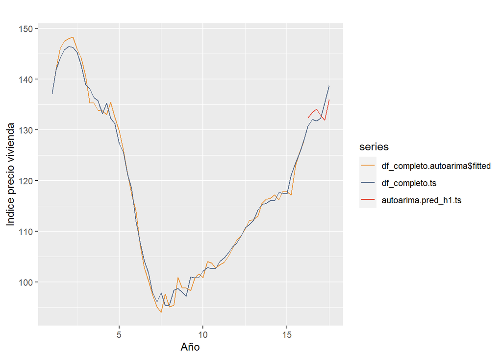

```r
autoarima.pred_h1 = pred1(df_completo.ts, arima_pred1, completo_train_ends, completo_valid_ends)
autoarima.pred_h1.ts = ts(autoarima.pred_h1$Point.Forecast, start = completo_valid_starts, end = completo_valid_ends, frequency = 4)

autoplot(cbind(df_completo.autoarima$fitted,df_completo.ts, autoarima.pred_h1.ts), xlab="Año", ylab="Indice precio vivienda") +
  scale_color_manual(values = c("#E8943A", "#566B8A", "#E34836"))
```

```r
bondad(df_completo.ts.valid, mean(df_completo.ts.valid), autoarima.pred_h1.ts)
```

```
## [1] "MAE: 2.042988"
## [1] "MAPE: 1.522266"
## [1] "RMSE: 2.23927"
## [1] "R^2*: 0.333522"
```

Al analizar la imagen del rendimiento de nuestro modelo, la línea roja que representa las predicciones de test muestra un ajuste razonable a los datos reales, aunque hay margen para mejorar. Los parámetros de desempeño del modelo son:

- **MAE: 2.042988**, que indica la diferencia media entre los valores predichos y los reales.
- **MAPE: 1.522266%**, que refleja el porcentaje medio de error en las predicciones.
- **RMSE:** **2.23927**, proporcionando una medida de la calidad del modelo en cuanto a la variabilidad de los errores de predicción.
- **R^2: 0.333522**, lo cual sugiere que nuestro modelo explica aproximadamente un 33.35% de variabilidad con respecto a un modelo ingenuo.

Estos indicadores de desempeño nos muestran que, aunque las predicciones son generalmente cercanas a los valores reales, debemos trabajar en la mejora del modelo para aumentar la precisión y la capacidad explicativa del mismo.

### Modelo con los datos a partir de 2014

Después de haber analizado modelos que incluyen el rango completo de datos históricos, ahora vamos a enfocarnos en los datos a partir de 2014. Esta fecha marca un hito significativo, ya que corresponde al siguiente trimetre después del punto más bajo en el precio de la vivienda.

Al limitar nuestro análisis a este periodo de tiempo más reciente, esperamos no solo simplificar la complejidad del modelo sino también aumentar la precisión de nuestras predicciones al concentrarnos en un mercado inmobiliario que ha mostrado una dinámica distinta en comparación con el comportamiento previo a 2014. Este enfoque segmentado nos permitirá ajustar mejor nuestros modelos a las tendencias actuales.

Continuamos con nuestro plantemiento de conseguir predicciones a medio y a corto plazo, pudiendo suponer dos modelos distintos.

```r
# Definimos ciertas variables genéricas de nuestro análisis
train_ends = c(9, 1)
valid_starts = c(9, 2)
valid_ends = c(10, 3)
```

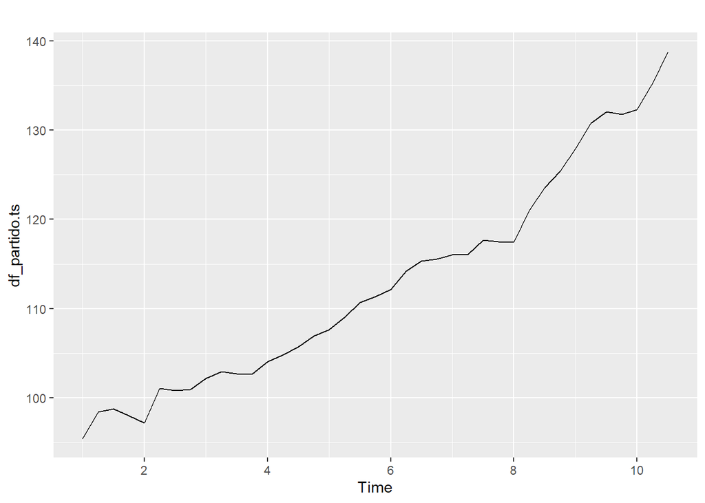

```r
df_partido = df %>% filter(year(Periodo) >= 2014)

df_partido.ts<-ts(df_partido$Precio_vivienda, start=c(1,1), end=c(10,3), freq = 4)

autoplot(df_partido.ts)
```

Este gráfico representa los datos con los que vamos a trabajar para obtener los modelos.

```r
df_partido.ts.train<-window(df_partido.ts,start = c(1,1), end = train_ends)
df_partido.ts.valid<-window(df_partido.ts,start = valid_starts, end = valid_ends)
```

#### Predicción a medio plazo

En primer lugar ajustaremos una serie de funciones matemáticas que nos permitan modelar y entender la evolución del precio de la vivienda durante el periodo que comienza en 2014. Consideraremos tres tipos de modelos de regresión para capturar la naturaleza de los datos: lineal, cuadrático y exponencial cuadrático. Seguidamente, al igual que hicimos anteriormente entrenaremos un modelo ARIMA para ver si es capaz de mejorar las predicciones de los modelos funcionales.

**Modelo Lineal**: Este será nuestro punto de partida, proporcionando una línea recta que representa la tendencia general de los precios de la vivienda con el tiempo. La simplicidad del modelo lineal lo hace útil para obtener una vista general y puede servir como una herramienta de comparación para modelos más complejos.

```r
df_partido.lm<-tslm(df_partido.ts.train~trend)
```

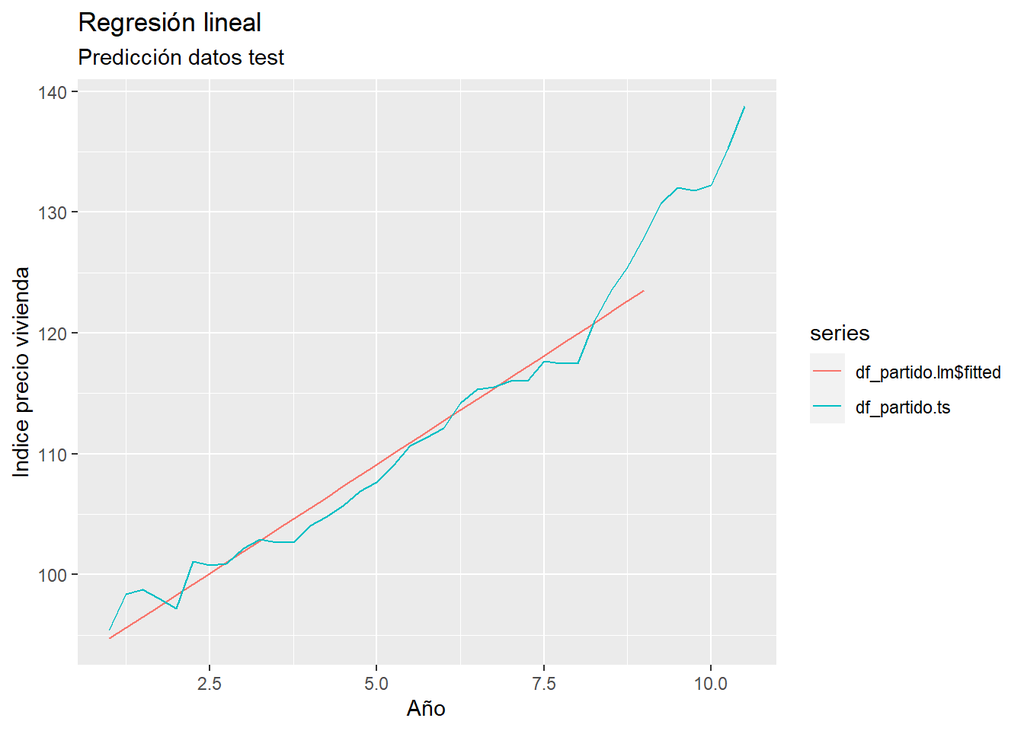

```r
autoplot(cbind(df_partido.lm$fitted,df_partido.ts), xlab="Año", ylab="Indice precio vivienda") + labs(
  title = "Regresión lineal",
  subtitle = "Predicción datos test",
)
```

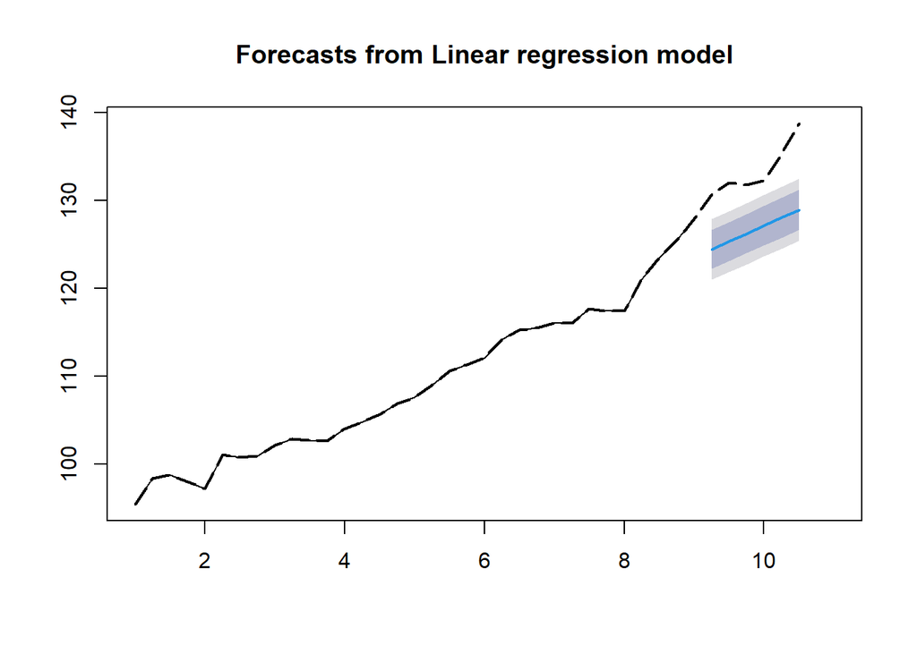

```r
a = df_partido.lm.pred.valid <- forecast(df_partido.lm, h = length(df_partido.ts.valid))

d = plotarimapred(df_partido.ts, df_partido.lm.pred.valid, xlim=c(1,valid_ends[1]+1), range.percent = 0.001)
```

```r
b = bondad(df_partido.ts.valid, mean(df_partido.ts.valid), df_partido.lm.pred.valid$mean)
```

```
## [1] "MAE: 6.776814"
## [1] "MAPE: 5.058521"
## [1] "RMSE: 6.94718"
## [1] "R^2*: -5.414901"
```

**Modelo Cuadrático**: Ampliando el modelo lineal, el modelo cuadrático introducirá un término de segundo grado, permitiéndonos capturar no solo la tendencia, sino también la aceleración o desaceleración de los precios a lo largo del tiempo. Esto podría reflejar cambios en el mercado que no son evidentes en un ajuste lineal.

```r
df_partido.lm2<-tslm(df_partido.ts.train~ I(trend^2) + trend)

summary(df_partido.lm2)
```

```
##
## Call:
## tslm(formula = df_partido.ts.train ~ I(trend^2) + trend)
##
## Residuals:
##     Min      1Q  Median      3Q     Max
## -3.1811 -0.5400  0.0698  0.6713  2.2426
##
## Coefficients:
##              Estimate Std. Error t value Pr(>|t|)
## (Intercept) 96.410966   0.650174 148.285  < 2e-16 ***
## I(trend^2)   0.013141   0.002516   5.224 1.24e-05 ***
## trend        0.454602   0.088167   5.156 1.50e-05 ***
## ---
## Signif. codes:  0 '***' 0.001 '**' 0.01 '*' 0.05 '.' 0.1 ' ' 1
##
## Residual standard error: 1.17 on 30 degrees of freedom
## Multiple R-squared:  0.9836, Adjusted R-squared:  0.9825
## F-statistic: 901.2 on 2 and 30 DF,  p-value: < 2.2e-16
```

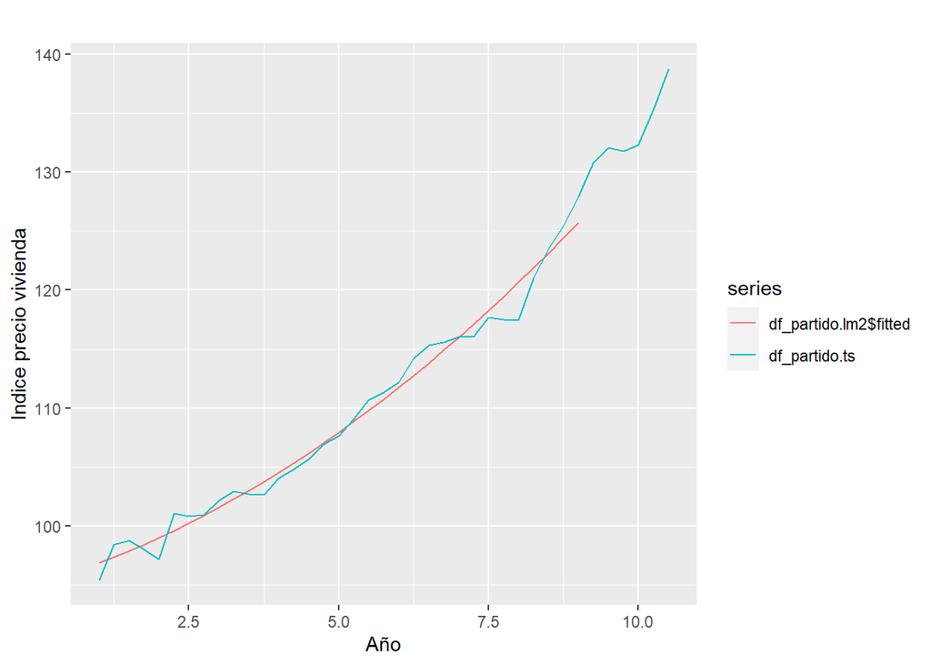

```r
# Ajuste de datos entrenamiento
autoplot(cbind(df_partido.lm2$fitted,df_partido.ts), xlab="Año", ylab="Indice precio vivienda")
```

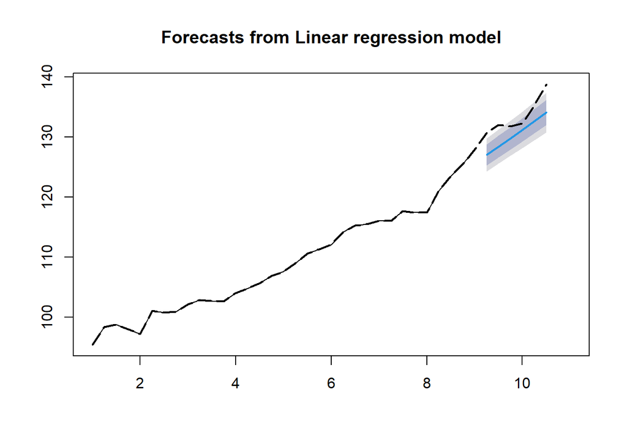

```r
# Ajuste datos de test
df_partido.lm2.pred.valid <- forecast(df_partido.lm2, h = length(df_partido.ts.valid))

plotarimapred(df_partido.ts, df_partido.lm2.pred.valid, xlim=c(1,valid_ends[1]+1), range.percent = 0.001)
```

```r
bondad(df_partido.ts.valid, mean(df_partido.ts.valid), df_partido.lm2.pred.valid$mean)
```

```
## [1] "MAE: 2.933056"
## [1] "MAPE: 2.189799"
## [1] "RMSE: 3.168091"
## [1] "R^2*: -0.334038"
```

**Modelo Exponencial Cuadrático**: Finalmente, el modelo exponencial cuadrático es considerablemente más complejo y nos ayudará a entender comportamientos no lineales en los datos. Esta función puede ser adecuada para modelar crecimientos que se aceleran a un ritmo no constante, lo que podría ocurrir en un mercado inmobiliario que experimenta cambios rápidos debido a factores económicos, demográficos o políticos.

```r
df_partido.exp<-tslm(df_partido.ts.train~I(trend^2) + trend, lambda = 0)

summary(df_partido.exp)
```

```
##
## Call:
## tslm(formula = df_partido.ts.train ~ I(trend^2) + trend, lambda = 0)
##
## Residuals:
##       Min        1Q    Median        3Q       Max
## -0.026367 -0.004996  0.001251  0.006450  0.016880
##
## Coefficients:
##              Estimate Std. Error t value Pr(>|t|)
## (Intercept) 4.567e+00  5.772e-03 791.160  < 2e-16 ***
## I(trend^2)  8.488e-05  2.233e-05   3.801 0.000658 ***
## trend       5.331e-03  7.827e-04   6.811 1.48e-07 ***
## ---
## Signif. codes:  0 '***' 0.001 '**' 0.01 '*' 0.05 '.' 0.1 ' ' 1
##
## Residual standard error: 0.01039 on 30 degrees of freedom
## Multiple R-squared:  0.9843, Adjusted R-squared:  0.9833
## F-statistic: 943.1 on 2 and 30 DF,  p-value: < 2.2e-16
```

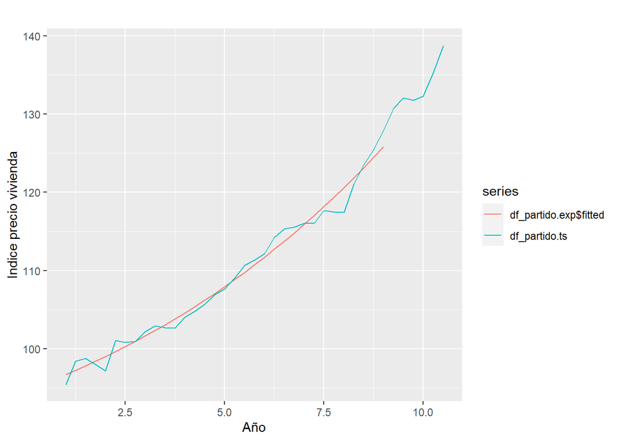

```r
# Ajuste de datos entrenamiento
autoplot(cbind(df_partido.exp$fitted,df_partido.ts), xlab="Año", ylab="Indice precio vivienda")
```

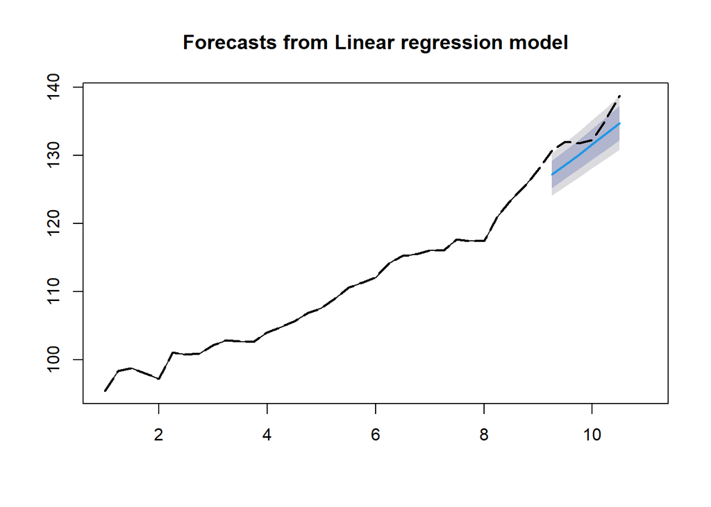

```r
# Ajuste datos de test
df_partido.exp.pred.valid <- forecast(df_partido.exp, h = length(df_partido.ts.valid))

plotarimapred(df_partido.ts, df_partido.exp.pred.valid, xlim=c(1,valid_ends[1]+1), range.percent = 0.001)
```

```r
bondad(df_partido.ts.valid, mean(df_partido.ts.valid), df_partido.exp.pred.valid$mean)
```

```
## [1] "MAE: 2.556409"
## [1] "MAPE: 1.909823"
## [1] "RMSE: 2.819245"
## [1] "R^2*: -0.056425"
```

**Modelo ARIMA**

```r
df_partido.autoarima<-auto.arima(df_partido.ts.train)

df_partido.autoarima
```

```
## Series: df_partido.ts.train
## ARIMA(0,1,0) with drift
##
## Coefficients:
##        drift
##       1.0160
## s.e.  0.2045
##
## sigma^2 = 1.382:  log likelihood = -50.07
## AIC=104.15   AICc=104.56   BIC=107.08
```

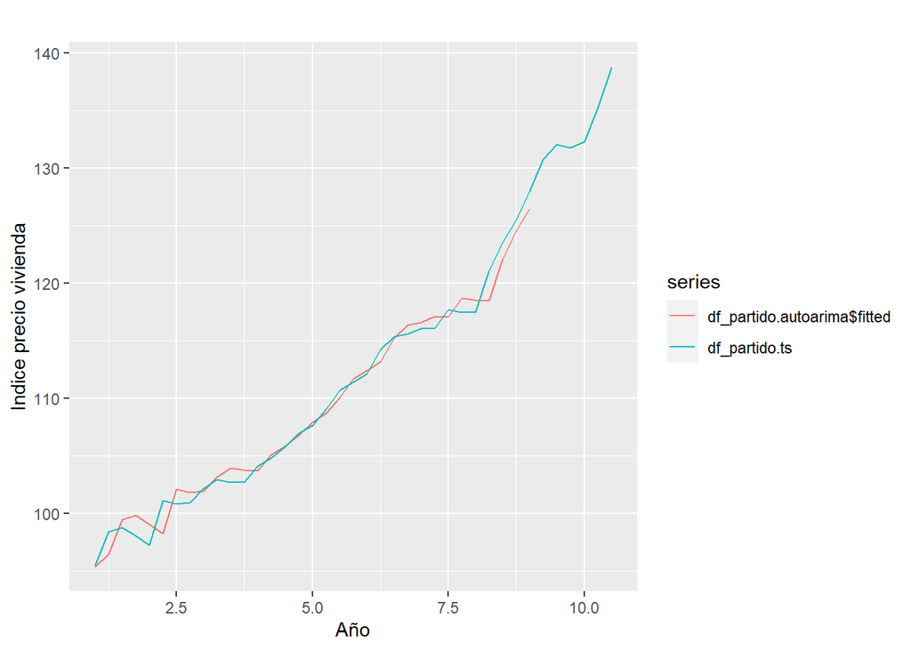

```r
# Ajuste de datos entrenamiento
autoplot(cbind(df_partido.autoarima$fitted,df_partido.ts), xlab="Año", ylab="Indice precio vivienda")
```

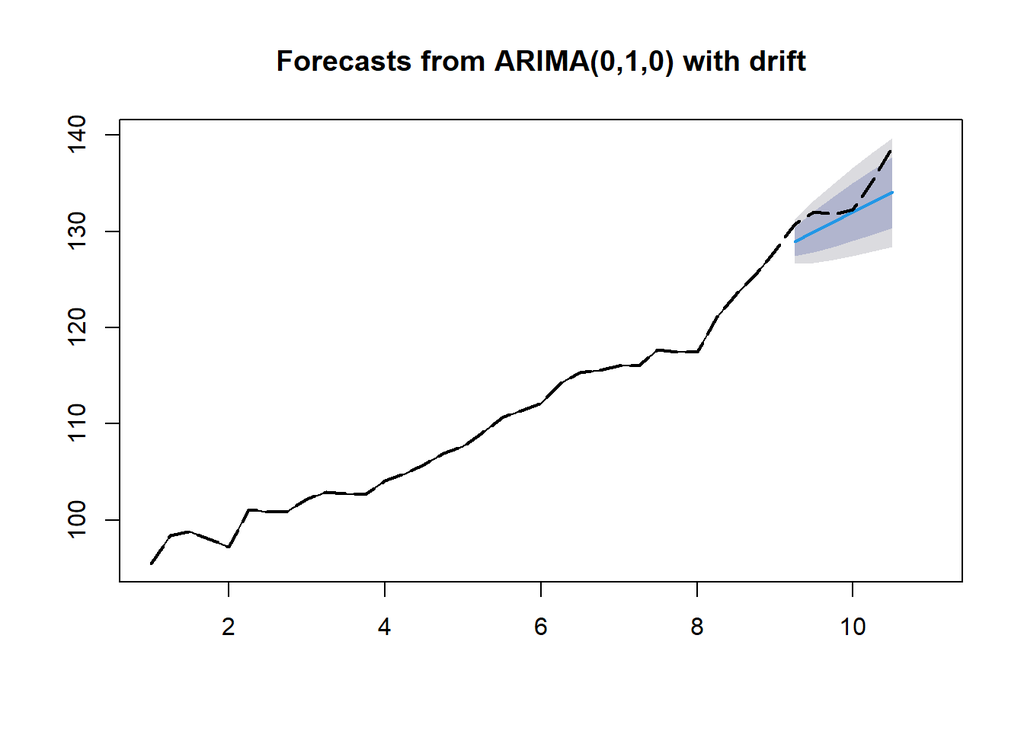

```r
# Ajuste datos de test
df_partido.autoarima.pred.valid <- forecast(df_partido.autoarima, h = length(df_partido.ts.valid))

plotarimapred(df_partido.ts, df_partido.autoarima.pred.valid, xlim=c(1,valid_ends[1]+1), range.percent = 0.001)
```

```r
bondad(df_partido.ts.valid, mean(df_partido.ts.valid), df_partido.autoarima.pred.valid$mean)
```

```
## [1] "MAE: 1.960391"
## [1] "MAPE: 1.451403"
## [1] "RMSE: 2.42105"
## [1] "R^2*: 0.220923"
```

#### Predicciones a corto plazo

Ahora vamos a ver como se comporta este modelo para predecir a un trimestre vista con una regresión cuadrática.

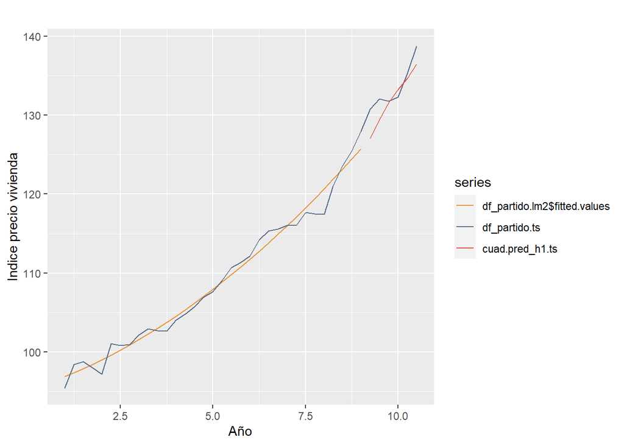

```r
cuad_pred1 = function(ts, trimestre) {
  df_partido.ts.train = window(df_partido.ts,start=c(1,1),end=trimestre)
  df_partido.lm2 = tslm(df_partido.ts.train~ I(trend^2) + trend)
  pred = forecast(df_partido.lm2, h = 1)
  pred
}

cuad.pred_h1 = pred1(df_completo.ts, cuad_pred1, train_ends, valid_ends)

cuad.pred_h1.ts = ts(cuad.pred_h1$Point.Forecast, start = valid_starts, end = valid_ends, frequency = 4)


# Ajuste de datos entrenamiento
autoplot(cbind(df_partido.lm2$fitted.values,df_partido.ts, cuad.pred_h1.ts), xlab="Año", ylab="Indice precio vivienda") +
  scale_color_manual(values = c("#E8943A", "#566B8A", "#E34836"))
```

```r
bondad(df_partido.ts.valid, mean(df_partido.ts.valid), cuad.pred_h1.ts)
```

```
## [1] "MAE: 1.744905"
## [1] "MAPE: 1.309773"
## [1] "RMSE: 2.138936"
## [1] "R^2*: 0.391909"
```

Exponencial cuadrática

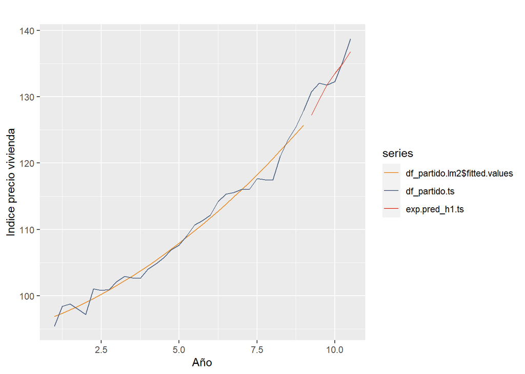

```r
exp_pred1 = function(ts, trimestre) {
  df_partido.ts.train = window(df_partido.ts,start=c(1,1),end=trimestre)
  df_partido.lm2 = tslm(df_partido.ts.train~ I(trend^2) + trend, lambda = 0)
  pred = forecast(df_partido.lm2, h = 1)
  pred
}

exp.pred_h1 = pred1(df_partido.ts, exp_pred1, train_ends, valid_ends)
exp.pred_h1.ts = ts(exp.pred_h1$Point.Forecast, start = valid_starts, end = valid_ends, frequency = 4)


# Ajuste de datos entrenamiento
autoplot(cbind(df_partido.lm2$fitted.values,df_partido.ts, exp.pred_h1.ts), xlab="Año", ylab="Indice precio vivienda") +
  scale_color_manual(values = c("#E8943A", "#566B8A", "#E34836"))
```

```r
bondad(df_partido.ts.valid, mean(df_partido.ts.valid), exp.pred_h1.ts)
```

```
## [1] "MAE: 1.589145"
## [1] "MAPE: 1.19486"
## [1] "RMSE: 1.999377"
## [1] "R^2*: 0.468673"
```

Arima:

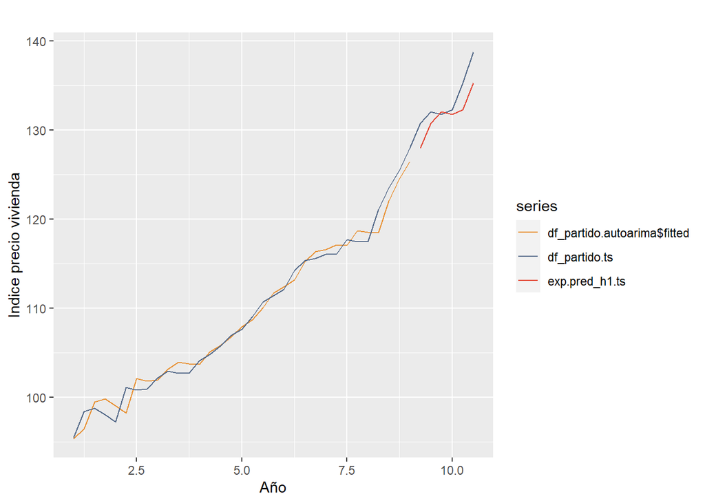

```r
arima2_pred1 = function(ts, trimestre) {
  df_partido.ts.train = window(df_partido.ts,start=c(1,1),end=trimestre)
  modelo = Arima(df_partido.ts.train, order = c(0, 1, 0))
  pred = forecast(modelo, h = 1)
  pred
}

exp.pred_h1 = pred1(df_partido.ts, arima2_pred1, train_ends, valid_ends)
exp.pred_h1.ts = ts(exp.pred_h1$Point.Forecast, start = valid_starts, end = valid_ends, frequency = 4)


# Ajuste de datos entrenamiento
autoplot(cbind(df_partido.autoarima$fitted, df_partido.ts, exp.pred_h1.ts), xlab="Año", ylab="Indice precio vivienda") +
  scale_color_manual(values = c("#E8943A", "#566B8A", "#E34836"))
```

```r
bondad(df_partido.ts.valid, mean(df_partido.ts.valid), exp.pred_h1.ts)
```

```
## [1] "MAE: 1.895833"
## [1] "MAPE: 1.408711"
## [1] "RMSE: 2.275515"
## [1] "R^2*: 0.311772"
```